# Customer Satisfaction Analysis - AIRLINERS FLIGHTS Case Study

Álvaro Fornells, Javier Simón, Alejandro Gonzalez, Adriano García

2025-05-10

## **Introduction and Objective Definition**

As members of **AIRLINERS FLIGHTS**’s analytics team, we have been tasked with a **critical objective**: to understand the current state of **customer satisfaction** and provide **actionable recommendations** to improve it. In an increasingly competitive airline industry, delivering a **high-quality customer experience** is essential not only for **retention and loyalty**, but also for strengthening the brand’s reputation and ensuring long-term profitability.

This report analyzes customer satisfaction data from over 100,000 passengers to uncover key service drivers and improvement areas. By combining **descriptive statistics** with **predictive modeling**, we identify the **main drivers of satisfaction and dissatisfaction** across key service areas—such as inflight entertainment, booking experience, onboard service, and digital support.

Our goal is to deliver an **understanding** of what matters most to our passengers, and to propose **focused strategies** that *AIRLINERS FLIGHTS* can implement to enhance the customer experience in a **measurable and sustainable way**.

We **aim** to analyze and **predict customer satisfaction** in the airline “AIRLINERS FLIGHTS”, in order to improve the customer experience and reduce dissatisfaction.

To develop this study we will focus on **answering the following questions**:

## **Literature Review: Customer Satisfaction in the Airline Industry**

Improving customer satisfaction has become a strategic imperative for airlines competing in increasingly saturated markets. Studies using microeconometric and statistical modeling offer insights into the main service attributes that influence passenger perception and loyalty. This review shows academic literature studies relevant to this business case.

### **Service Quality as a Core Driver of Satisfaction**

Namukasa (2013) explores airline service quality and its impact on passenger satisfaction and loyalty. The study finds that **on-time performance, staff service, and seat comfort** are major predictors. The paper also highlights that **passengers’ perception of value mediates the satisfaction–loyalty relationship**.

> Namukasa, J. (2013). The influence of airline service quality on passenger satisfaction and loyalty: The case of Uganda airline industry. *The TQM Journal, 25*(5), 520–532. https://doi.org/10.1108/TQM-11-2012-0092

### **Modeling Satisfaction with Service Attributes**

Akamavi, Mohamed, Pellmann, and Xu (2015) develop a satisfaction model for airline services using survey data and regression analysis. They identify **online check-in, digital interfaces, in-flight amenities, and crew professionalism** as the strongest determinants of satisfaction. Their framework supports the use of **predictive modeling for service design**.

> Akamavi, R. K., Mohamed, E., Pellmann, K., & Xu, Y. (2015). Key determinants of passenger loyalty in the low-cost airline business. *Tourism Management, 46*, 528–545. https://doi.org/10.1016/j.tourman.2014.07.013

### **Passengers’ Perceptions of Inflight Services**

Ali, Kim, and Ryu (2016) examine the role of **inflight entertainment**, **food quality**, and **seat comfort** in forming perceived value and satisfaction. Their findings indicate that **entertainment has one of the strongest effects**, especially on long-haul flights.

> Ali, F., Kim, W. G., & Ryu, K. (2016). The effect of physical environment on passenger delight and satisfaction: Moderating effect of national identity. *Tourism Management, 57*, 213–224. https://doi.org/10.1016/j.tourman.2016.06.004

### **Satisfaction and Behavioral Intentions**

Park, Park, and Zhang (2016) use structural equation modeling to link satisfaction with **future intention to repurchase and recommend**. Their results emphasize the role of **service personalization**, **ease of boarding**, and **mobile platform design**.

> Park, J. W., Park, J., & Zhang, Y. (2016). The impact of service quality and value on satisfaction and behavioral intention in low-cost carriers. *Journal of Air Transport Management, 53*, 70–82. https://doi.org/10.1016/j.jairtraman.2016.01.001

### **Collect and Manage Data**

```r
knitr::opts_chunk$set(echo = TRUE, warning = FALSE, message = FALSE)

library(tidyverse)
library(ggplot2)
library(caret)
library(gridExtra)
library(scales)
library(car)
library(lmtest)
```

```r
data <- read.csv("Airline_customer_satisfaction.csv")

# Fix satisfaction levels
data$satisfaction <- tolower(trimws(data$satisfaction))
data$satisfaction <- factor(data$satisfaction, levels = c("dissatisfied", "satisfied"))

# Remove rows with missing Arrival Delay
data <- data[!is.na(data$Arrival.Delay.in.Minutes), ]
```

In this section, we load the required R libraries and import the dataset for analysis.

We clean the data by standardizing the satisfaction labels and removing rows with missing values in the arrival delay variable.

This ensures data consistency and prepares the dataset for accurate modeling and interpretation.

## Exploratory Data Analysis

## **Overall Satisfaction Level**

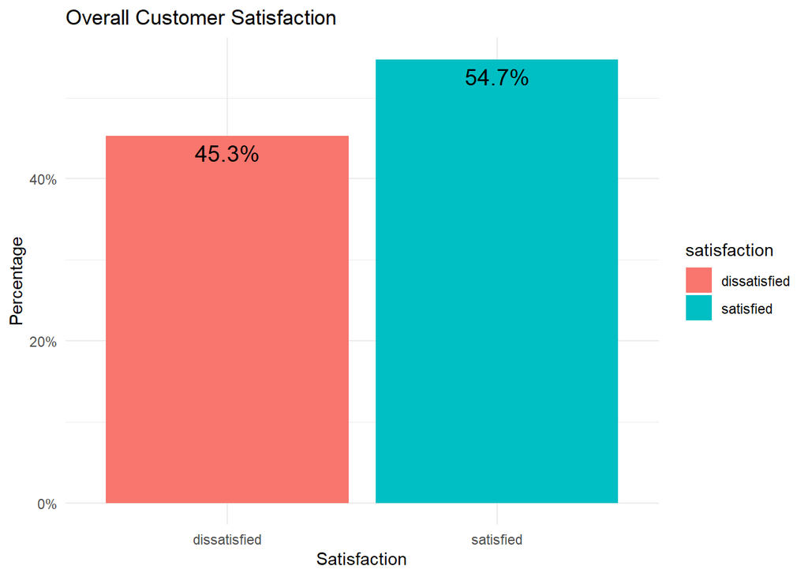

```r
ggplot(data, aes(x = satisfaction, fill = satisfaction)) +
  geom_bar(aes(y = (..count..) / sum(..count..))) +
  geom_text(aes(label = scales::percent((..count..) / sum(..count..), accuracy = 0.1),
                y = (..count..) / sum(..count..)),
            stat = "count", vjust = 1.5, size = 5) +
  scale_y_continuous(labels = percent_format(accuracy = 1)) +
  labs(title = "Overall Customer Satisfaction", x = "Satisfaction", y = "Percentage") +
  theme_minimal()
```

The bar chart shows that **45.3% of customers are dissatisfied**. Although a slight majority are satisfied, the margin is relatively narrow, indicating that nearly half of the customers is not having a positive experience.

This indicates that there is much **room for improvement**, so we will study in depth what causes this dissatisfaction.

## **Satisfaction by Customer Type**

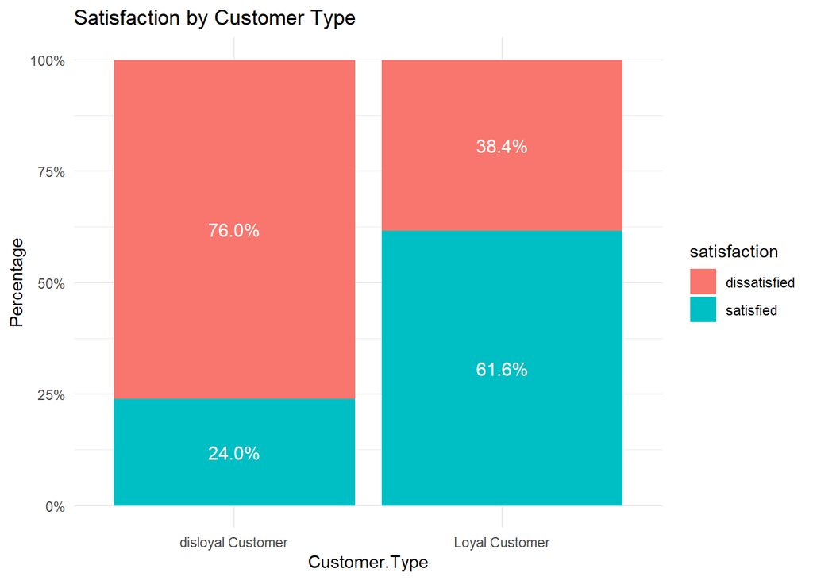

```r
ggplot(data, aes(x = Customer.Type, fill = satisfaction)) +
  geom_bar(position = "fill") +
  geom_text(stat = "count",
            aes(label = scales::percent(..count../tapply(..count.., ..x.., sum)[..x..], accuracy = 0.1)),
            position = position_fill(vjust = 0.5), size = 4, color = "white") +
  scale_y_continuous(labels = percent_format()) +
  labs(title = "Satisfaction by Customer Type", y = "Percentage") +
  theme_minimal()
```

This chart reveals a clear **contrast between loyal and disloyal customers**.

It suggests that **Customer Loyalty is closely linked to customer experience**; either because loyal customers receive better service or because those who have positive experiences are more likely to remain loyal.

On the other hand, **more than three quarters of disloyal customers are dissatisfied with their experience**, which may be the reason why they haven’t been loyal.

## **Satisfaction by Travel Class**

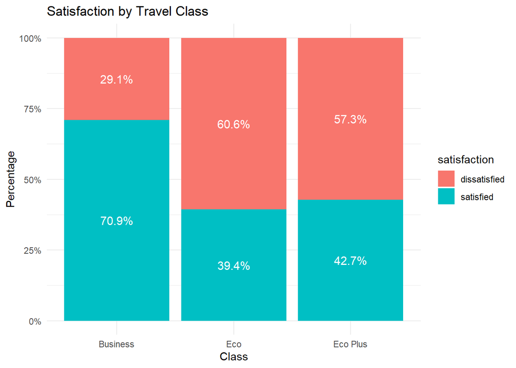

```r
ggplot(data, aes(x = Class, fill = satisfaction)) +
  geom_bar(position = "fill") +
  geom_text(stat = "count",
            aes(label = scales::percent(..count../tapply(..count.., ..x.., sum)[..x..], accuracy = 0.1)),
            position = position_fill(vjust = 0.5), size = 4, color = "white") +
  scale_y_continuous(labels = percent_format()) +
  labs(title = "Satisfaction by Travel Class", y = "Percentage") +
  theme_minimal()
```

This chart shows **clear differences in satisfaction levels depending on the class of travel**. Customers flying in **Business Class** report the highest satisfaction, with over **70% satisfied**. In contrast, **Economy and Eco Plus** passengers show the lowest satisfaction rates, with **more than half reporting dissatisfaction**.

It is interesting to note that **between Eco and Eco Plus classes there is not much difference**. The difference between Eco (39.4% satisfied) and Eco Plus (42.7% satisfied) is relatively small.

From a **business perspective**, this suggests that the added cost and **advantages of Eco Plus may not be perceived as valuable** enough by customers to notably **improve their experience.**

## **Services: Difference in Average Service Rating (Satisfied - Dissatisfied)**

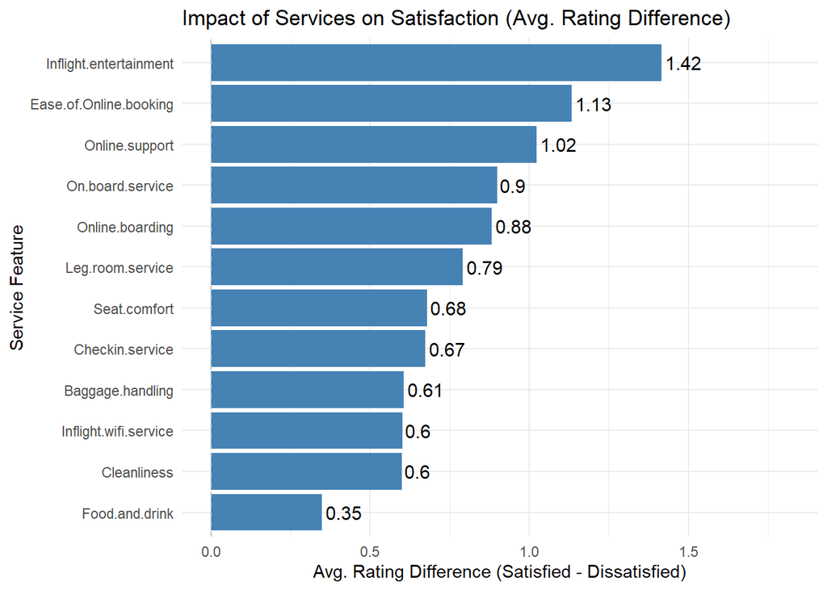

```r
service_vars <- c("Seat.comfort", "Food.and.drink", "Inflight.wifi.service",
                  "Inflight.entertainment", "Online.support", "Ease.of.Online.booking",
                  "On.board.service", "Leg.room.service", "Baggage.handling",
                  "Checkin.service", "Cleanliness", "Online.boarding")

library(tidyr)
long_services <- data %>%
  select(satisfaction, all_of(service_vars)) %>%
  pivot_longer(-satisfaction, names_to = "Service", values_to = "Rating")


service_diff <- long_services %>%
  group_by(Service, satisfaction) %>%
  summarise(avg_rating = mean(Rating, na.rm = TRUE), .groups = "drop") %>%
  pivot_wider(names_from = satisfaction, values_from = avg_rating) %>%
  mutate(diff = satisfied - dissatisfied)

ggplot(service_diff, aes(x = reorder(Service, diff), y = diff)) +
  geom_col(fill = "steelblue") +
  geom_text(aes(label = round(diff, 2)),
            hjust = -0.1, size = 4) +
  coord_flip() +
  labs(title = "Impact of Services on Satisfaction (Avg. Rating Difference)",
       x = "Service Feature",
       y = "Avg. Rating Difference (Satisfied - Dissatisfied)") +
  geom_hline(yintercept = 0, linetype = "dashed", color = "gray") +
  theme_minimal() +
  expand_limits(y = max(service_diff$diff) + 0.4)
```

This graph shows the difference in average ratings for each service feature between satisfied and dissatisfied customers, meaning: **(Average rating of the service by satisfied customers - Average rating of the service by dissatisfied customers)**. The larger the difference, the more that service appears to influence customer satisfaction.

The **services with the biggest impact** on customer satisfaction are:

- **Inflight Entertainment**
- **Ease of Online Booking**
- **Online Support**

These areas show the largest rating differences between satisfied and dissatisfied customers, so **improving them can significantly boost satisfaction.**

From a business perspective, we suggest the company to **focus investments** on:

1. **Improving the digital experience** (online-booking and support) by improving the usability and design of the **webpage**.
2. Make sure the customers have numerous available **options to entertain** themselves during the flight. To do so, we suggest to **expand the digital contents** offered in the flight, and invest in its variety **(movies, games, audio)**.

## **Model Build: Customer Satisfaction**

```r
model_data <- data %>% select(satisfaction, Age, Flight.Distance,
                              Departure.Delay.in.Minutes, Arrival.Delay.in.Minutes,
                              Seat.comfort, Food.and.drink, Inflight.wifi.service,
                              Inflight.entertainment, Online.support,
                              Ease.of.Online.booking,
                              On.board.service, Leg.room.service, Baggage.handling,
                              Checkin.service, Cleanliness, Online.boarding)

model_data <- na.omit(model_data)
model_data$satisfaction <- as.numeric(model_data$satisfaction) - 1

model <- glm(satisfaction ~ ., data = model_data, family = binomial)
summary(model)
```

```
##
## Call:
## glm(formula = satisfaction ~ ., family = binomial, data = model_data)
##
## Coefficients:
##                              Estimate Std. Error  z value Pr(>|z|)
## (Intercept)                -6.972e+00  5.363e-02 -129.990  < 2e-16 ***
## Age                         6.423e-03  5.023e-04   12.787  < 2e-16 ***
## Flight.Distance            -1.136e-05  7.649e-06   -1.485 0.137654
## Departure.Delay.in.Minutes  2.438e-03  7.450e-04    3.273 0.001064 **
## Arrival.Delay.in.Minutes   -7.256e-03  7.333e-04   -9.895  < 2e-16 ***
## Seat.comfort                1.802e-01  8.676e-03   20.770  < 2e-16 ***
## Food.and.drink             -2.580e-01  8.178e-03  -31.555  < 2e-16 ***
## Inflight.wifi.service      -1.314e-01  8.380e-03  -15.682  < 2e-16 ***
## Inflight.entertainment      8.664e-01  7.470e-03  115.986  < 2e-16 ***
## Online.support              1.663e-01  8.233e-03   20.194  < 2e-16 ***
## Ease.of.Online.booking      3.960e-01  1.066e-02   37.169  < 2e-16 ***
## On.board.service            2.985e-01  7.479e-03   39.913  < 2e-16 ***
## Leg.room.service            2.533e-01  6.459e-03   39.218  < 2e-16 ***
## Baggage.handling            3.043e-02  8.454e-03    3.600 0.000319 ***
## Checkin.service             2.262e-01  6.312e-03   35.832  < 2e-16 ***
## Cleanliness                -9.556e-03  8.745e-03   -1.093 0.274498
## Online.boarding             2.840e-02  9.309e-03    3.051 0.002280 **
## ---
## Signif. codes:  0 '***' 0.001 '**' 0.01 '*' 0.05 '.' 0.1 ' ' 1
##
## (Dispersion parameter for binomial family taken to be 1)
##
##     Null deviance: 178341  on 129486  degrees of freedom
## Residual deviance: 114623  on 129470  degrees of freedom
## AIC: 114657
##
## Number of Fisher Scoring iterations: 5
```

#### **Check for Multicollinearity**

```r
vif(model)
```

```
##                        Age            Flight.Distance
##                   1.090494                   1.087109
## Departure.Delay.in.Minutes   Arrival.Delay.in.Minutes
##                  13.242463                  13.248125
##               Seat.comfort             Food.and.drink
##                   2.359250                   2.357683
##      Inflight.wifi.service     Inflight.entertainment
##                   2.140608                   1.417718
##             Online.support     Ease.of.Online.booking
##                   1.951060                   3.107566
##           On.board.service           Leg.room.service
##                   1.520075                   1.208938
##           Baggage.handling            Checkin.service
##                   1.720509                   1.133297
##                Cleanliness            Online.boarding
##                   1.822398                   2.529876
```

Arrival Delay and Departure Delay seem to be correlated.

```r
reduced_model_data <- data %>%
  select(satisfaction,
         Inflight.entertainment,
         Ease.of.Online.booking,
         On.board.service,
         Checkin.service)

reduced_model_data <- na.omit(reduced_model_data)
reduced_model_data$satisfaction <- as.numeric(reduced_model_data$satisfaction) - 1

reduced_model <- glm(satisfaction ~ ., data = reduced_model_data, family = binomial)
summary(reduced_model)
```

```
##
## Call:
## glm(formula = satisfaction ~ ., family = binomial, data = reduced_model_data)
##
## Coefficients:
##                         Estimate Std. Error z value Pr(>|z|)
## (Intercept)            -6.527626   0.038267 -170.58   <2e-16 ***
## Inflight.entertainment  0.860159   0.006300  136.54   <2e-16 ***
## Ease.of.Online.booking  0.499397   0.006252   79.88   <2e-16 ***
## On.board.service        0.369279   0.006349   58.16   <2e-16 ***
## Checkin.service         0.253919   0.005934   42.79   <2e-16 ***
## ---
## Signif. codes:  0 '***' 0.001 '**' 0.01 '*' 0.05 '.' 0.1 ' ' 1
##
## (Dispersion parameter for binomial family taken to be 1)
##
##     Null deviance: 178341  on 129486  degrees of freedom
## Residual deviance: 118816  on 129482  degrees of freedom
## AIC: 118826
##
## Number of Fisher Scoring iterations: 5
```

```r
AIC(model, reduced_model)
```

```
##               df      AIC
## model         17 114657.2
## reduced_model  5 118826.0
```

### **Reduced Model Decision**

Although the **full logistic regression model provides a slightly better fit** (AIC = 114657, ((Null. Dev - Resid. Dev)/Null. Dev) = 0.357), a **reduced model was selected for the final analysis**, because we believe it is better from a business analysis perspective.

The **reduced model maintains strong explanatory power** (AIC = 118826, ((Null. Dev - Resid. Dev)/Null. Dev) = 0.334) while **focusing** only on the most **impactful variables** and variables in which the **business can take action**.

We are making a **trade-off**: sacrificing a small amount of statistical performance to gain interpretability, simplicity, and business impact.

## **Model Coefficients Interpretation:**

### **Impact of Each Variable on Customer Satisfaction:**

As the variables are a 1-5 rating, we will interpret the coefficients with a 1 point increase in the rating.

- **Inflight Entertainment**
  - A 1-point increase in rating → **+136%** in odds of satisfaction  
    *Shows it is a top driver of satisfaction, as it more than doubles the likelihood*
- **Ease of Online Booking**
  - A 1-point increase → **+65%** in odds  
    *Improving usability and simplicity of booking strongly boosts satisfaction*
- **On-board Service**
  - A 1-point increase → **+45%** in odds  
    *Better crew service and onboard experience matter greatly*
- **Check-in Service**
  - A 1-point increase → **+29%** in odds  
    *Smooth and fast check-in tend to make the customer satisfied*
- **Intercept**
  - Represents the base odds when a ll predictors are 0  
    *(Not interpretable)*

# **Final Analysis and Business Recommendations**

The customer satisfaction study conducted for AIRLINERS FLIGHTS has revealed key factors that significantly influence passengers’ experiences. Although a slight majority of customers are satisfied (54.7%), a substantial 45.3% report dissatisfaction. This highlights a critical need for strategic improvements to enhance service quality and passenger retention.

#### **Key Findings**

**Customer Loyalty Matters:** Loyal customers report much higher satisfaction (61.6%) than disloyal ones (24%). This suggests that improving satisfaction can also drive long-term loyalty, leading to more repeat customers.

**Class of Travel Has a Strong Impact:** Business class passengers are far more satisfied (70.9%) than those in Eco (39.4%) and Eco Plus (42.7%). Interestingly, Eco and Eco Plus yield similar satisfaction levels, which indicates that Eco Plus may not be perceived as significantly better despite its higher price point.

## **Business Recommendations to Increase Customer Satisfaction**:

Based on the complete analysis of customer satisfaction at *AIRLINERS FLIGHTS*, including descriptive statistics, service ratings, and predictive modeling with GLM, here is an actionable **set of business recommendations and policies** for the company:

### **Strategic Business Recommendations to Improve Customer Satisfaction**

#### 1. **Improve the Inflight Entertainment System**

- **Why?** It’s the most influential factor in the model (+136% increase in satisfaction odds per rating point).
- **Actions:**
  - Modernize the hardware (screens, plugs).
  - Regularly update content (movies, shows, games, music).
  - Offer content in multiple languages.

#### 2. **Optimize the Online Booking Experience**

- **Why?** Ease of online booking is the second most impactful variable (+65% satisfaction odds).
- **Actions:**
  - Redesign the booking interface for clarity and ease of use.
  - Reduce the number of steps to complete a booking.
  - Provide better mobile optimization.

#### 3. **Improve On-board Service**

- **Why?** Directly linked to satisfaction (+45% satisfaction odds).
- **Actions:**
  - Train cabin crew in hospitality and conflict resolution.
  - Reward high-performing crew based on passenger feedback.

#### 4. **Streamline Check-in Services**

- **Why?** Check-in process shows a +29% effect on satisfaction.
- **Actions:**
  - Introduce early check-in notifications via app/email.
  - Offer baggage drop-off priority for loyal customers.

#### 5. **Loyalty Program Reinforcement**

- **Why?** Loyal customers report significantly higher satisfaction (62% vs 24% in disloyal ones).
- **Actions:**
  - Offer exclusive advantages for loyal customers (priority boarding, free seat selection).
  - Provide targeted loyalty bonuses for repeat customers.
  - Launch campaigns to reactivate non-loyal customers with discounts.

#### 6. **Repositioning of Eco Plus**

- **Why?** Business class shows clear value (71% satisfaction), but Eco Plus is not significantly better than Economy Class.
- **Actions:**
  - Reevaluate the pricing of Eco Plus.
  - Add differentiators like more legroom or free snacks/beverage.

This analysis has shown that while a **slight majority of customers are satisfied**, nearly **45% report dissatisfaction**, revealing a **clear opportunity for improvement**.

### **BIBLIOGRAPHY**

> **Huseyn, R.** (2024). *Airline customer satisfaction* [Data set]. Kaggle. https://www.kaggle.com/datasets/raminhuseyn/airline-customer-satisfaction

> **Rivas, M. V.** (2025). *Microeconometrics course materials* [Class materials]. Moodle, Universidad Autónoma de Madrid.